# Numerical Methods of Accelerator Physics

## Lecture by Dr. Adrian Oeftiger

[figure not shown]

### Part 3: 04.11.2022

## Run this notebook online!

Interact and run this jupyter notebook online:

1. via the public mybinder.org service:

2. on the [local TU Darmstadt jupyterhub $\nearrow$](https://tu-jupyter-i.ca.hrz.tu-darmstadt.de/) (using your TU ID)

$\implies$ make sure you installed all the required python packages (see the README)!

Finally, also find this lecture rendered [as HTML slides on github $\nearrow$](https://aoeftiger.github.io/TUDa-NMAP-03/) along with the [source repository $\nearrow$](https://github.com/aoeftiger/TUDa-NMAP-03).

## Announcements

Starting flipped classroom next week:

- first video material: lecture part 4
  - available on moodle by Monday night, 7.11.2022
  - please watch it until Friday, 11.11.2022
  - note your questions
- Friday, 11.11.2022:
  - lecture time: discuss open questions & solve problems together

## Refresher!

- coordinate system: $\zeta=(x,x',y,y',z,\delta)$
- rms **emittance** (phase-space area, thermal energy)
- non-linearities and **filamentation**: microscopic level (Liouville theorem) vs. macroscopic level (emittance growth)
- **emittance preservation** and injection **mismatch**
- **modelling error** (vs. discretisation error)
- discrete frequency analysis:
  - **FFT**: Fast Fourier Transform
  - **NAFF**: Numerical Analysis of Fundamental Freqencies

## Today!

1. Chaos and Early Indicators
2. Numerical artefacts: rounding and truncation

## Non-linearities

Non-linearities in particle dynamics can originate from e.g.:

- **stray fields** in drift spaces
- higher-order **multipole components** in dipole magnets (steering) and quadrupole magnets (focusing)
- higher-order **multipole magnets** (sextupoles, octupoles) used to control various properties of the beam
- effects of **beam fields** on individual particles within the beam (space-charge forces, beam-beam effects when colliding two beams)

Effects can be varied and quite dramatic! $\implies$ require understanding of nonlinear dynamics to optimise design and operation of many accelerator systems!

## Effects of Non-linearities

Design accelerator based on linear quasi-periodic oscillations $\implies$ focusing around reference particle, phase-space trajectory should be an ellipse!

Non-linearities in beam lines can have several effects:

- shape of phase-space ellipse can become distorted
- phase advance per period (frequency) can depend on oscillation amplitude
- motion can be stable for small amplitude but unstable at large amplitude: chaotic motion
- features such as "phase-space islands" can appear in phase-space portrait

## Chaotic Dynamics

[figure not shown]

**Tentative definition**:

- sensitive to initial conditions: *butterfly effect*
- qualitatively recurring

but chaos is **not**:

- (strictly) periodic or **regular**
- "escalating"

[image by Ari Rubinsztejn](https://commons.wikimedia.org/wiki/File:Demonstrating_Chaos_with_a_Double_Pendulum.gif)

### ... what is the problem?

$\implies$ motion **not predictable** despite of deterministic dynamics! (correct initial condition? numerical precision? ...)

$\implies$ cannot exclude sudden changes of amplitude on long-term time scales (synchrotron storage times) from **short-term simulations** in case of chaotic motion!

## Deterministic Chaos

**Necessary condition**: non-linearity

*"The exponential divergence or convergence of nearby trajectories (Lyapunov exponents) is conceptually the most basic indicator of deterministic chaos."*

M. Sano and Y. Sawada (1985)  
Phys. Rev. Lett. **55**, 1082

**One possible conceptual approach**:

deterministic chaos $\doteq$ "bounded, deterministic dynamics with a positive Lyapunov exponent."

## (Maximum) Lyapunov Exponent

Consider two nearby trajectories $\zeta_1, \zeta_2$ evolving over path length $s$:

- infinitesimal distance $|\zeta_1-\zeta_2|\rightarrow 0$
- infinite evolution $s\rightarrow \infty$

Chaotic behaviour if distance grows or shrinks exponentially:

$$|\zeta_1(s_0 + s) - \zeta_2(s_0 + s)| = \underbrace{|\zeta_1(s_0) - \zeta_2(s_0)|}\limits_{\Delta\zeta(s_0)} \cdot e^{\lambda_1 s}$$

$\implies$ $\lambda_1$: maximum **Lyapunov exponent**

$$ \lambda_1 \doteq \lim\limits_{s\rightarrow \infty}\,\lim\limits_{\Delta\zeta(s_0)\rightarrow 0}\,\frac{1}{s}\,\ln\left(\frac{\Delta\zeta(s_0+s)}{\Delta\zeta(s_0)}\right)$$

## Lyapunov Spectrum

When chaotic: perturbation aligns along direction of strongest expansion (or weakest contraction), associated with maximum Lyupunov exponent

$\implies$ orthogonal directions for further Lyapunov exponents $\lambda_i$

$\implies$ as many $\lambda_i$ as phase-space coordinates

## Example: Lorenz Attractor

Studied by E. Lorenz in 1963 for atmospheric convection:

[figure not shown]

$$\begin{align} \frac{dx}{dt}&=\sigma(y-x) \\ \frac{dy}{dt}&=x(\rho - z) - y \\ \frac{dz}{dt}&=xy - \beta z \end{align}$$

Lorenz used $\sigma=10, \beta=\frac{8}{3}, \rho=28$ and investigated chaotic motion.

[image by Dan Quinn](https://commons.wikimedia.org/wiki/File:A_Trajectory_Through_Phase_Space_in_a_Lorenz_Attractor.gif)

## Chaotic Motion in Lorenz Attractor

Two identical Lorenz oscillators with initial conditions. Second oscillator is slightly perturbed ($10^{-14}$) at $t = 30$:

[figure not shown]

[image by G. Ansmann](https://www.ukbonn.de/site/assets/files/22947/02-wt-dynsystchaos.pdf)

```python
from config import (np, plt, hamiltonian,
                    plot_hamiltonian, solve_leapfrog, dt)
%matplotlib inline
```

```python
N = 11

thetas = np.linspace(0, 0.99 * np.pi, 11)
ps = np.zeros_like(thetas)
```

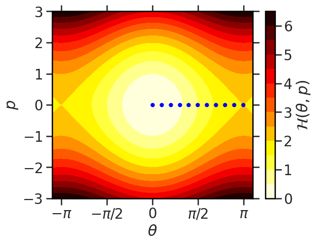

```python
plt.scatter(thetas, ps, c='b', marker='.')

plot_hamiltonian()
```

## Time evolution

Numerical integration of equations of motion for distribution of pendulums, using leapfrog (drift+kick+drift):

```python
n_steps = 1000
```

```python
results_thetas = np.zeros((n_steps, N), dtype=np.float32)
results_thetas[0] = thetas

results_ps = np.zeros((n_steps, N), dtype=np.float32)
results_ps[0] = ps

for k in range(1, n_steps):
    results_thetas[k], results_ps[k] = solve_leapfrog(results_thetas[k - 1], results_ps[k - 1])
```

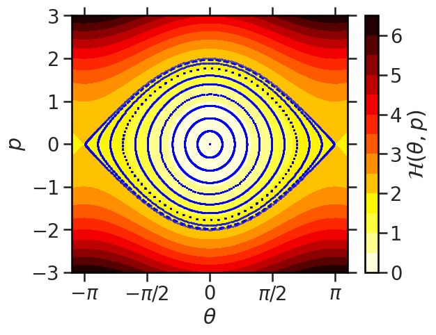

```python
plt.scatter(results_thetas, results_ps, c='b', marker='.', s=1)

plot_hamiltonian()
```

## Chaos near Unstable Fixed Point

```python
N = 2

thetas = np.pi * np.ones(N, dtype=np.float32)
ps = np.linspace(0.01, 0.05, N)
```

```python
results_thetas2 = np.zeros((n_steps, N), dtype=np.float32)
results_thetas2[0] = thetas

results_ps2 = np.zeros((n_steps, N), dtype=np.float32)
results_ps2[0] = ps

for k in range(1, n_steps):
    results_thetas2[k], results_ps2[k] = solve_leapfrog(results_thetas2[k - 1], results_ps2[k - 1])
```

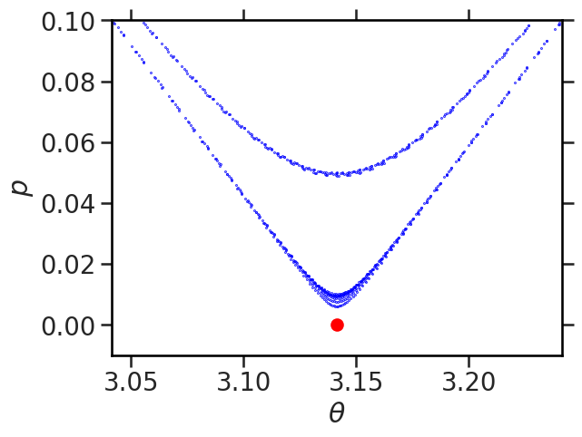

```python
plt.scatter(results_thetas2 % (2*np.pi), results_ps2, c='b', marker='.', s=1)
plt.scatter([np.pi], [0], c='r', marker='o')

plt.xlim(np.pi - 0.1, np.pi + 0.1)
plt.ylim(-0.01, 0.1)
plt.xlabel(r'$\theta$')
plt.ylabel(r'$p$')
```

$\implies$ observation near red unstable fixed point:

- phase-space trajectory becomes non-regular, obvious during subsequent passages when wrapping $\theta$ to interval $\bigl[0, 2\pi\bigr)$

## Qualitative Investigation of Local Lyapunov Exponent

First around stable fixed point $\theta=0$, $p=0$ -- then around unstable fixed point $\theta=\pi$, $p=0$:

```python
dist = 1e-10

thetas = np.pi * np.ones(N, dtype=np.float64) # change this line
ps = np.array([0.001, 0.001 + dist], dtype=np.float64)
```

```python
n_steps = 100000
```

```python
results_thetas3 = np.zeros((n_steps, N), dtype=np.float64)
results_thetas3[0] = thetas

results_ps3 = np.zeros((n_steps, N), dtype=np.float64)
results_ps3[0] = ps

for k in range(1, n_steps):
    results_thetas3[k], results_ps3[k] = solve_leapfrog(results_thetas3[k - 1], results_ps3[k - 1])
```

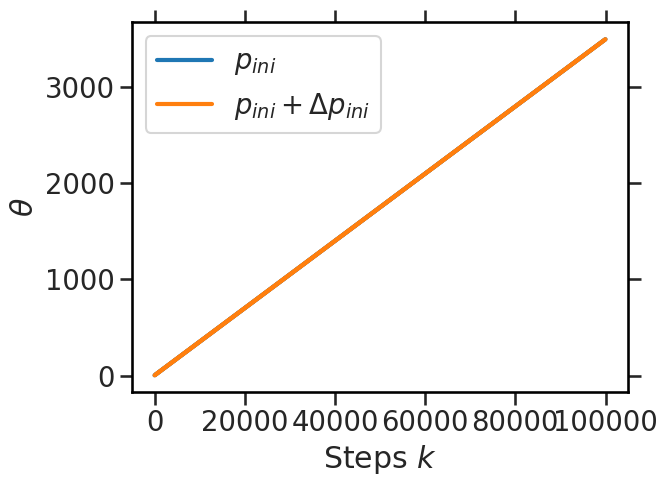

```python
plt.plot(results_thetas3[:, 0], label='$p_{ini}$')
plt.plot(results_thetas3[:, 1], label='$p_{ini} + \Delta p_{ini}$')

plt.xlabel('Steps $k$')
plt.ylabel(r'$\theta$')
plt.legend();
```

## Distance $|(\theta_2,p_2)-(\theta_1,p_1)|$

```python
results_dist = np.sqrt(
    (results_thetas3[:, 1] - results_thetas3[:, 0])**2 +
    (results_ps3[:, 1] - results_ps3[:, 0])**2
)
```

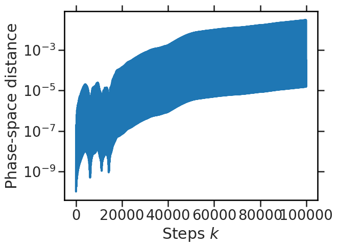

```python
plt.plot(results_dist)

plt.yscale('log')
plt.xlabel('Steps $k$')
plt.ylabel('Phase-space distance');
```

## Frequency Diffusion

Use NAFF algorithm as early indicator of chaotic motion in periodic systems:

Regular orbits $\Longleftrightarrow$ fixed frequency up to numerical accuracy!

vs.

Non-regular orbits $\Longleftrightarrow$ frequency evolves in time indicating chaotic diffusion of orbit!

Further reading: "Introduction to Frequency Map Analysis" by J. Laskar in [Hamiltonian Systems with Three or More Degrees of Freedom, Springer (1999), pp. 134-150](https://link.springer.com/content/pdf/10.1007/978-94-011-4673-9.pdf)

## Example: Earth-Moon System

Precession of Earth is stabilised by presence of Moon:

[figure not shown]

[image by J. Laskar](https://link.springer.com/content/pdf/10.1007/978-94-011-4673-9.pdf)

## Example: CERN LHC

[figure not shown]

Frequency Map Analysis (FMA) to identify diffusion due to non-linear resonances:

$\implies$ always seek to maximise dynamic aperture in accelerators

$\implies$ use of "early chaos indicators" such as Lyapunov exponents or FMA: identification and mitigation/correction of sources

[image by Y. Papaphilippou](https://aip.scitation.org/doi/pdf/10.1063/1.4884495)

## Try Concept on Discrete Pendulum

Can we detect frequency diffusion in discrete pendulum?

```python
n_steps = 100000
```

```python
theta_ini = np.pi - 0.001
p_ini = 0
```

```python
results_thetas4 = np.zeros(n_steps, dtype=np.float64)
results_thetas4[0] = theta_ini

results_ps4 = np.zeros(n_steps, dtype=np.float64)
results_ps4[0] = p_ini

for k in range(1, n_steps):
    results_thetas4[k], results_ps4[k] = solve_leapfrog(results_thetas4[k - 1], results_ps4[k - 1])
```

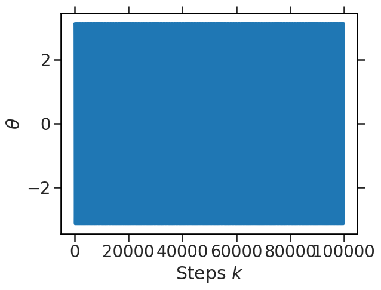

```python
plt.plot(results_thetas4)

plt.xlabel('Steps $k$')
plt.ylabel(r'$\theta$');
```

```python
import PyNAFF
```

```python
window_length = 1000

freqs_naff = []

for signal in results_thetas4.reshape((n_steps // window_length, window_length)):
    freq_naff = PyNAFF.naff(signal - np.mean(signal), turns=window_length, nterms=1)[0, 1]
    freqs_naff += [freq_naff]
```

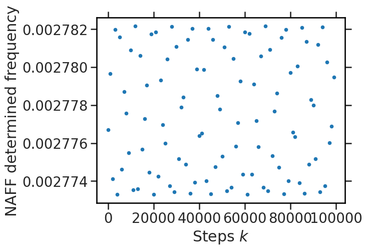

```python
plt.plot(np.arange(0, n_steps, window_length), freqs_naff, ls='none', marker='.')

plt.xlabel('Steps $k$')
plt.ylabel('NAFF determined frequency');

# plt.ylim(1.59e-2, 1.6e-2)
```

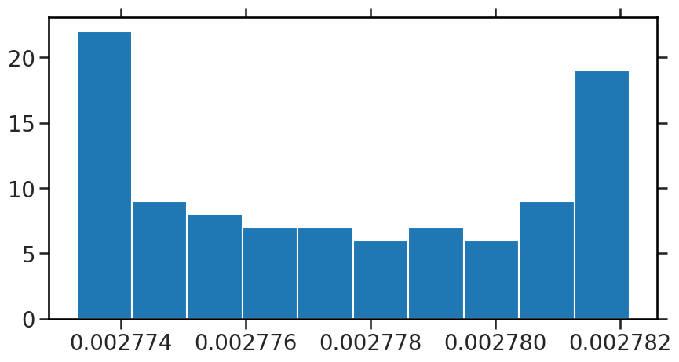

```python
plt.figure(figsize=(10, 5))
plt.hist(freqs_naff);
```

## Summing up Concepts

- sources for non-linearities in accelerators
- deterministic chaos: (bounded) deterministic dynamics with a positive Lyapunov exponent
  - sensitivity to initial conditions
  - prevents prediction for long-term time scales
- early indicators of chaos:
  - (maximum) Lyapunov exponent
  - Frequency Map Analysis (FMA)

## Floating Point Representation

Represent real numbers $r\in\mathbb{R}$ on computers by "floats":

- finite and discrete set of numbers
- floating-point form: $r=\underbrace{6.022}\limits_\text{significand}\times 10{\underbrace{{}^{23}}\limits_\text{exponent}}$

Todays standard: IEEE 754

$r=\pm a \times 2^{e}$

e.g. a "single-precision" float (FP32):

- 1 sign bit
- $t=23$ bits for significand $a$
- 8 bits for exponents in range $e\in[-126, 127]$
- $\pm\infty$ and NaN

## Numerical Artefacts

Floating point representation of numbers on computers $\leadsto$ numerical artefacts:

- rounding: storing the least significant bit depending on arithmetic operation
- truncating: e.g. π cannot be stored exactly but is truncated

Smallest "machine" precision in resolving real numbers: $2^{-t}$

Accumulation of errors $\implies$ gradual loss of significance

## (Drastic) Example of Truncation Error

The python library `mpmath` works with arbitrary numerical precision (`workdps` for decimal precision):

```python
import mpmath as mp

with mp.workdps(7):
    x = mp.mpf(10) / 9   # == 1.11...

    for _ in range(30):
        print (x)
        x = (x - 1) * 10
```

```
1.111111
1.111111
1.11111
1.111104
1.111045
1.110449
1.104488
1.044884
0.4488373
-5.511627
-65.11627
-661.1627
-6621.627
-66226.27
-662272.7
-6622737.0
-6.622738e+7
-6.622738e+8
-6.622738e+9
-6.622738e+10
-6.622738e+11
-6.622738e+12
-6.622738e+13
-6.622738e+14
-6.622738e+15
-6.622738e+16
-6.622738e+17
-6.622738e+18
-6.622738e+19
-6.622738e+20
```

## Overview: Sources of Simulation Errors

1. Discretisation error
2. Modelling error
3. Numerical artefacts
4. Input error...

## Summary

- sources for non-linearities in accelerators
- deterministic chaos
- early indicators:
  - (maximum) Lyapunov exponent
  - Frequency Map Analysis
- numerical artefacts: rounding and truncation, machine precision

## Literature

- chapter 2.1 in Justin Solomon, [Numerical Algorithms](https://people.csail.mit.edu/jsolomon/share/book/numerical_book.pdf)